# CCLasso vs SparCC

Avril Metcalfe-Roach

2024-09-06

CCLasso and SparCC are two correlation matrix-based network analysis methods. They use similar approaches, but CCLasso is a newer method that addresses some of the limitations of SparCC, helping to limit spurious correlations. CCLasso also provides P values, whereas SparCC doesn’t (they can be estimated via permutation testing, but this isn’t straightforward or necessarily common).

Here are the CCLasso and SparCC functions: https://github.com/huayingfang/CCLasso

And the paper that compares the methods: https://academic.oup.com/bioinformatics/article/31/19/3172/211784

# 1. Preparation

CCLasso does not have its own package - we just have to download the functions for CCLasso and SparCC and then source them so they can be used. We will download them to our Networks folder for easy use.

```r
#download.file('https://raw.githubusercontent.com/huayingfang/CCLasso/master/R/SparCC.R',
#               'Networks/SparCC_function.R')
# download.file('https://raw.githubusercontent.com/huayingfang/CCLasso/master/R/cclasso.R',
#               'Networks/CCLasso_function.R')
```

We will then load the necessary packages and functions.

```r
library(tidyverse)
library(gtools) # Necessary for the network functions
library(pheatmap) # For visualization
library(gridExtra) # To arrange the visualizations
library(igraph) # For network building

# Network functions
source("CCLasso_function.R")
source("SparCC_function.R")
```

# 2. Load data

We will use two sets of data:

- Dummy microbiome data (zero-inflated, approximate negative binomial distribution)
  - This will only be tested as counts, as relative abundance is confounded by the compositional nature of the data. The algorithms will automatically apply a normalization procedure to the count data.
- Control data (logistic normal data)
  - This will be tested as both counts and relative abundance.

Importantly, the control data should not contain any correlations between features, whereas the microbiome data should show correlations between commonly-associated taxa.

To create the control data, we can run the following code:

```r
set.seed(421)

# Parameters
n <- 100 # samples
p <- 20 # features
x <- matrix(rnorm(n * p), nrow = n) # normal distribution
totCount <- round(runif(n = n,  min = 1000, max = 2000)) # Fake total counts

# Create datasets
ctrlfrac <- exp(x) / rowSums(exp((x))) # logistic and RELATIVE abundance
ctrl <- ctrlfrac * totCount # Create the dummy COUNT data

# Add COLUMN/ROW names
samples = paste('Sample_',c(1:n),sep='')
features = paste('Feature_',c(1:p),sep='')
ctrlfrac = as.data.frame(ctrlfrac) %>% `colnames<-`(features) %>% `rownames<-`(samples)
ctrl = as.data.frame(ctrl) %>% `colnames<-`(features) %>% `rownames<-`(samples)

# Remove temp variables
rm(features,n,p,samples,totCount,x)
```

We will then also load the microbiome data, which also has 100 samples:

```r
df = read.csv('sample_otus_genus.csv',row.names = 1) %>% t() %>% as.data.frame()
# Edit names so that _unclassified becomes _unc
colnames(df) = sapply(colnames(df), function(x) str_replace(x,'_unclassified','_unc'))
```

In the CCLasso paper, they test their method using Human Microbiome Project data. Before they build their network, they filter the taxa to include only the OTUs that meet the following requirements:

- Mean reads > 2 across all samples
- Less than 60% zeros across all samples

We will therefore write a function to filter the datasets.

```r
filter_otus = function(data, cols_are_otus = T, min_reads = 2, max_zeros = 0.6){
  if(cols_are_otus==F){
    data = t(data) %>% as.data.frame()
  }
  data = data[,colMeans(data) >= min_reads] # Only include taxa with at least 2 avg reads
  pct = (data == 0) %>% colSums() # Number of samples with 0 reads
  data = data[,pct/nrow(data) < max_zeros] # Only taxa where the fraction of zeros is less than 60%
  if(cols_are_otus==F){
    data = t(data) %>% as.data.frame()
  }
  return(data)
}
```

This function is then applied to all count datasets. The relative abundance dataset will use the count dataset for filtration, since the mean reads won’t work on proportional data.

```r
df = filter_otus(df)
ctrl = filter_otus(ctrl)
ctrlfrac = ctrlfrac %>% select(all_of(names(ctrl)))
```

# 3. Run SparCC and CCLasso

## Run algorithms

SparCC is the older version of the algorithm (2012). Different functions are applied depending on whether the data are counts or relative abundance.

```r
sparcc_count_df <- SparCC.count(x = df)
sparcc_count_ctrl <- SparCC.count(x = ctrl)
sparcc_frac_ctrl <- SparCC.frac(x = ctrlfrac)
```

CCLasso is the newer version of the algorithm (2015). The data type is input as a parameter.

```r
cclasso_count_df <- cclasso(x = df, counts = T)
cclasso_count_ctrl <- cclasso(x = ctrl, counts = T)
cclasso_frac_ctrl <- cclasso(x = ctrlfrac, counts = F)
```

## Extract correlation matrices and P values

The correlation matrix for CCLasso is stored as cor_w, and cor.w for SparCC. We will also add the feature names back to the matrices to allow interpretation.

```r
mat_cclasso_count_df = cclasso_count_df$cor_w %>% `colnames<-`(colnames(df)) %>% `rownames<-`(colnames(df))
mat_cclasso_count_ctrl = cclasso_count_ctrl$cor_w %>% `colnames<-`(colnames(ctrl)) %>% `rownames<-`(colnames(ctrl))
mat_cclasso_frac_ctrl = cclasso_frac_ctrl$cor_w %>% `colnames<-`(colnames(ctrl)) %>% `rownames<-`(colnames(ctrl))

mat_sparcc_count_df = sparcc_count_df$cor.w %>% `colnames<-`(colnames(df)) %>% `rownames<-`(colnames(df))
mat_sparcc_count_ctrl = sparcc_count_ctrl$cor.w %>% `colnames<-`(colnames(ctrl)) %>% `rownames<-`(colnames(ctrl))
mat_sparcc_frac_ctrl = sparcc_frac_ctrl$cor.w %>% `colnames<-`(colnames(ctrl)) %>% `rownames<-`(colnames(ctrl))
```

P values are only available for CCLasso. This is stored under p_vals. We will transform the data so that any P value < 0.05 will be presented as an asterisk. We will use the Unicode “73B” instead of * so that it’s vertically centered.

We’ll only use the microbiome P values (see further below).

```r
# Microbiome
cclasso_count_df_pval = cclasso_count_df$p_vals
cclasso_count_df_pval[cclasso_count_df_pval<0.05] = '\U273B'
cclasso_count_df_pval[cclasso_count_df_pval!='\U273B'] = ''
```

# 4. Visualize the results

## 4a. Heatmaps

### Compare Data vs Ctrl, Counts vs Rel Ab, CCLasso vs SparCC

We will create heatmaps of the correlations, where the colour indicates the coefficient of correlation. When we use pheatmap to make the plots, the grob can be accessed as plot[[4]]. We can use grid.arrange from gridExtra to plot them side by side (since they’re not ggplot objects, we can’t use more typical arranging functions such as facet_wrap).

For now, we won’t add P values.

```r
# Function to make it tidier and more reproducible
make_plot = function(mat,title, # matrix and plot title
                     cols = F, rows = F, # Names of features
                     tree_r = 0, tree_c = 0, # Dendrogram (set to 0 if unwanted)
                     pvals=NULL,pvals_size=8){ # P value matrix and font size
  # graphics.off()
  if(is.matrix(pvals)){ # For CCLasso - pvals available
    p=pheatmap(mat, main = title, legend = TRUE,
           show_colnames = cols, show_rownames = rows,
           treeheight_row=tree_r, treeheight_col = tree_c,
           display_numbers = pvals,
           fontsize_number = pvals_size,
           fontsize_row=6,fontsize_col = 6)
  #graphics.off()
  } else { # No pvals for SparCC
    p=pheatmap(mat, main = title, legend = TRUE,
             show_colnames = cols, show_rownames = rows,
             treeheight_row=tree_r, treeheight_col = tree_c,
             fontsize_row=6,fontsize_col = 6)
    #graphics.off()
  }
  return(p)
}
```

```r
p1 = make_plot(mat_cclasso_count_df,title='CCLasso - Data - Count')[[4]]
```

```r
p2 = make_plot(mat_cclasso_count_ctrl,title='CCLasso - Ctrl - Count')[[4]]
```

```r
p3 = make_plot(mat_cclasso_frac_ctrl,title='CCLasso - Ctrl - Fraction')[[4]]
```

```r
p4 = make_plot(mat_sparcc_count_df,title='SparCC - Data - Count')[[4]]
```

```r
p5 = make_plot(mat_sparcc_count_ctrl,title='SparCC - Ctrl - Count')[[4]]
```

```r
p6 = make_plot(mat_sparcc_frac_ctrl,title='SparCC - Ctrl - Fraction')[[4]]
```

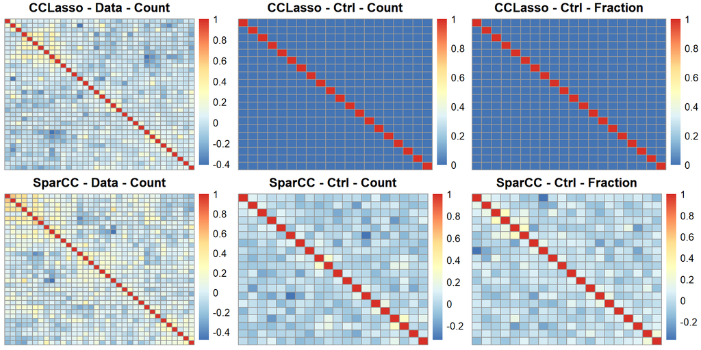

```r
grid.arrange(arrangeGrob(grobs = list(p1,p2,p3,p4,p5,p6), nrow=2, ncol=3))
```

We can see that the CCLasso algorithm does a better job in removing spurious correlations, as there are no detected correlations in the control data.

Let’s focus on the microbiome data and add more information: p values (CCLasso only), dendrograms, and feature labels.

```r
p11 = make_plot(mat_cclasso_count_df,title='CCLasso', cols = T, rows = T,
            tree_r = 0, tree_c = 5,
            pvals = cclasso_count_df_pval)[[4]]
```

```r
p44 = make_plot(mat_sparcc_count_df,title='SparCC',cols = T, rows = T,
            tree_r = 0, tree_c = 5)[[4]]
```

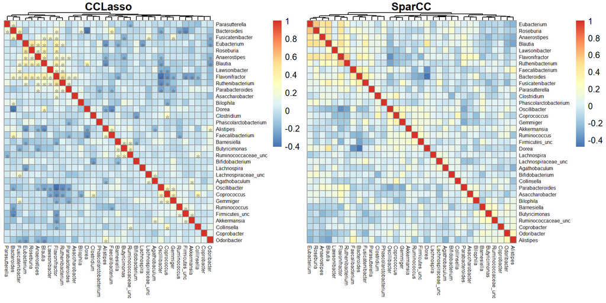

```r
grid.arrange(arrangeGrob(grobs = list(p11,p44), nrow=1, ncol=2))
```

## 4b. Network Diagrams

Let’s visualize these data using edges (correlations) and nodes (the features). We can use the igraph package for this.

Because SparCC doesn’t give P values, we’ll instead use a correlation coefficient cutoff.

*Note: the igraph is limited in terms of the plot parameters. For better control, it may be worth using ggplot2 in some cases.

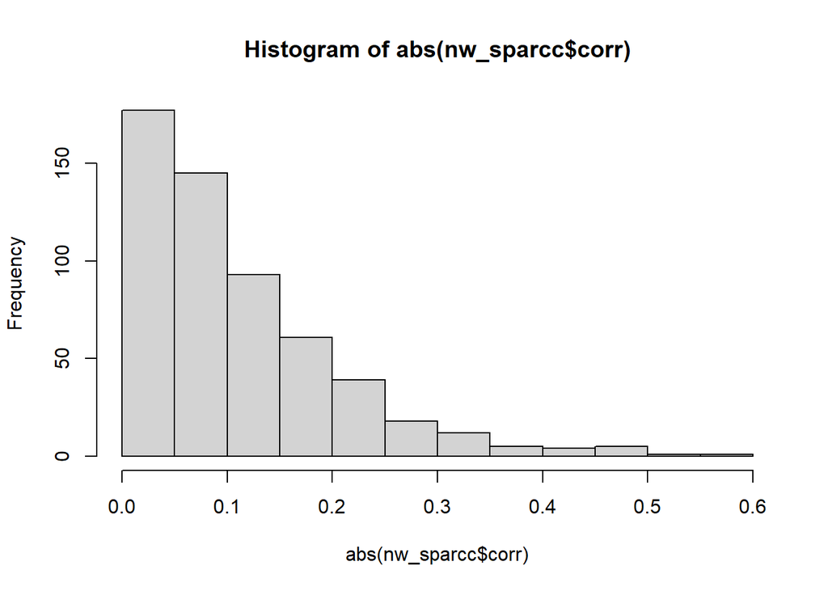

```r
# CCLasso

# Extract the correlation matrix. We don't want duplicates or the diagonal.
nw_cclasso = mat_cclasso_count_df
nw_cclasso[!upper.tri(nw_cclasso)] <- NA
# Pivot the table so that we have all possible pairs and filter out the NAs.
nw_cclasso = nw_cclasso %>% as.data.frame() %>%
  rownames_to_column('Feature_A') %>%
  pivot_longer(cols = -Feature_A, names_to = 'Feature_B', values_to = 'corr') %>%
  filter(!is.na(corr)) %>%
  mutate(weight = 10*abs(corr), # line thickness
         direction = ifelse(corr<0,'Red','Blue'))

# Repeat with the P value data frame and join them together.
nw_cclasso_p = cclasso_count_df$p_vals %>%
  `colnames<-`(colnames(df)) %>% `rownames<-`(colnames(df))
nw_cclasso_p[!upper.tri(nw_cclasso_p)] <- NA
nw_cclasso_p = nw_cclasso_p %>% as.data.frame() %>%
  rownames_to_column('Feature_A') %>%
  pivot_longer(cols = -Feature_A, names_to = 'Feature_B', values_to = 'pval') %>%
  filter(!is.na(pval))

nw_cclasso = left_join(nw_cclasso,nw_cclasso_p)
# Filter so that we only have connections that pass our P value threshold.
p_threshold = 0.05
nw_cclasso_filt = nw_cclasso %>% filter(pval<p_threshold)

# Create graph elements
g_cclasso = graph_from_data_frame(nw_cclasso_filt, directed = F)
E(g_cclasso)$color = E(g_cclasso)$direction
E(g_cclasso)$width = E(g_cclasso)$weight
V(g_cclasso)$color <- "black"
layout <- layout_with_fr(g_cclasso)
layout <- norm_coords(layout, -1, 1, -1, 1)

# SparCC ~~~~~~~~~~~~~~~~~~~~~~~~~~~~~~~~~~~~~~~~~~~~~~~~~~~~~~~~~~~~

# Extract the correlation matrix. We don't want duplicates or the diagonal.
nw_sparcc = mat_sparcc_count_df
nw_sparcc[!upper.tri(nw_sparcc)] <- NA
# Pivot the table so that we have all possible pairs and filter out the NAs.
nw_sparcc = nw_sparcc %>% as.data.frame() %>%
  rownames_to_column('Feature_A') %>%
  pivot_longer(cols = -Feature_A, names_to = 'Feature_B', values_to = 'corr') %>%
  filter(!is.na(corr)) %>%
  mutate(weight = 10*abs(corr), # line thickness
         direction = ifelse(corr<0,'Red','Blue'))

# For this tutorial, we'll use a histogram to determine what a reasonable coefficient cutoff might be.
# We don't want to be too stringent - otherwise our network will be too sparse.
# 0.2 gives us approximately as many hits as with CCLasso, so we'll use that.
hist(abs(nw_sparcc$corr))
```

```r
table(abs(nw_sparcc$corr)>0.2)
```

```
##
## FALSE  TRUE
##   476    85
```

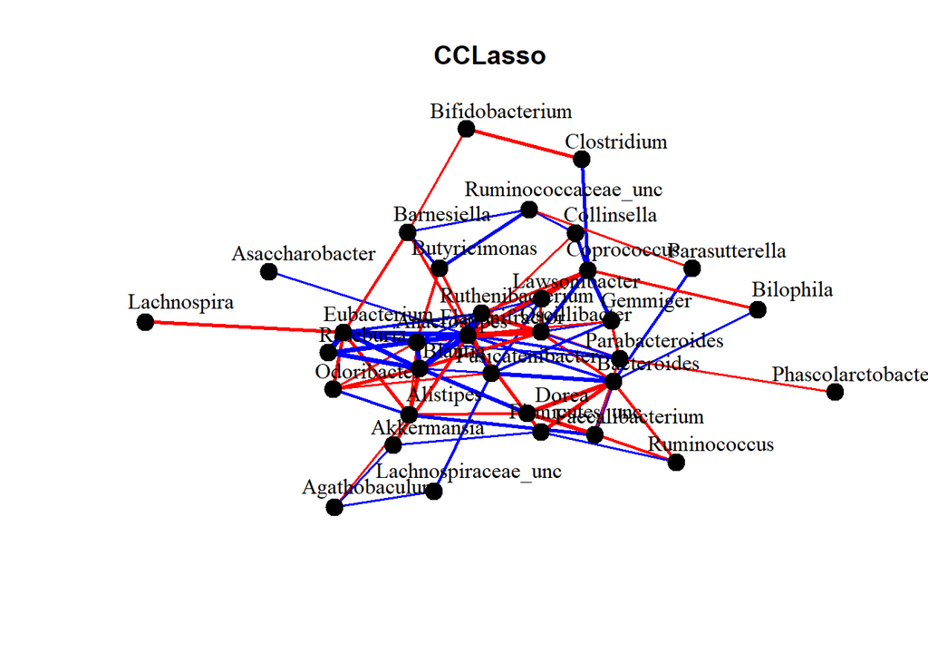

```r
nw_sparcc_filt = nw_sparcc %>% filter(abs(corr)>0.2)

# Create graph
g_sparcc = graph_from_data_frame(nw_sparcc_filt, directed = F)
E(g_sparcc)$color = E(g_sparcc)$direction
E(g_sparcc)$width = E(g_sparcc)$weight
V(g_sparcc)$color <- "black"


# Plot both networks ~~~~~~~~~~~~~~~~~~~~~~~~~~~~~~~~~~~~~~~~~~~~~~~~~~~~~~
layout <- layout_with_fr(g_cclasso)
layout <- norm_coords(layout, -1, 1, -1, 1)
plot(g_cclasso, layout = layout, main = 'CCLasso',
     vertex.size = 5,
     vertex.label.cex = 1,   # Adjust label size
     vertex.label.color = "black",
     vertex.color = V(g_cclasso)$color,  # Set vertex color to black
     vertex.label.dist = 2,
     edge.arrow.size = 0.5,
     asp = -1)  # Adjust aspect ratio
```

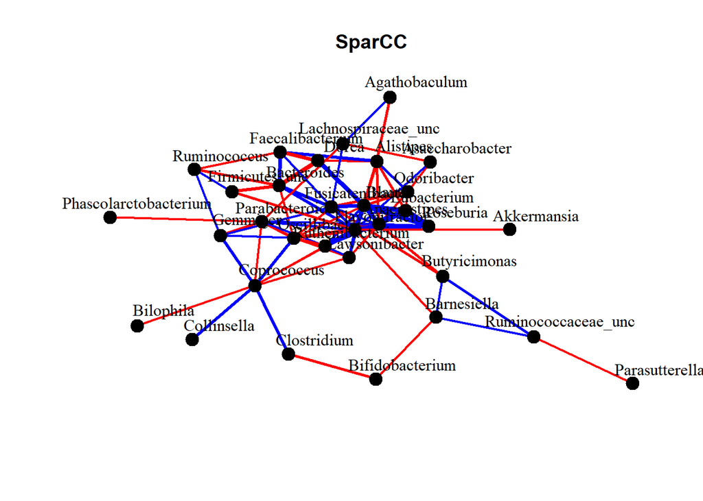

```r
layout <- layout_with_fr(g_sparcc)
layout <- norm_coords(layout, -1, 1, -1, 1)
plot(g_sparcc, layout = layout, main = 'SparCC',
     vertex.size = 5,
     vertex.label.cex = 1,   # Adjust label size
     vertex.label.color = "black",
     vertex.color = V(g_sparcc)$color,  # Set vertex color to black
     vertex.label.dist = 2,
     edge.arrow.size = 0.5,
     asp = -1)  # Adjust aspect ratio
```